# Project 1 : Expore Weather Trends

# Explore Weather Trends

#### This project is aim to analyze the global and my home city Taipei’s weather trends. By using Udacity workspace to extract data and using R to analyze.

#### *The submission will be submitted as a markdown version of HTML file.

1. Extract data
2. Calculate moving average
3. Visualization
4. Observation
5. Reference

## 1. Extract data

I used following SQL to extract target data from the database :

```
SELECT *
    FROM city_data
    WHERE country = 'Taiwan' AND city = 'Taipei'
    ORDER BY year

SELECT *
    FROM global_data
    ORDER BY year
```

## 2. Calculate moving average

After I downloaded those csv data, I loaded them to R studio and took a brief observation.

```r
# load the visualize package
library(ggplot2)
library(dplyr)
library(zoo)
# get the working directory
getwd()
```

```
## [1] "C:/Users/Weber/Desktop/Nanodegree/T1/P1"
```

```r
# load the csv data
Taipei <- read.csv("city_data.csv")
Global <- read.csv("global_data.csv")

# === observe and clean the data
# observe data
str(Taipei)
```

```
## 'data.frame':    173 obs. of  4 variables:
##  $ year    : int  1841 1842 1843 1844 1845 1846 1847 1848 1849 1850 ...
##  $ city    : Factor w/ 1 level "Taipei": 1 1 1 1 1 1 1 1 1 1 ...
##  $ country : Factor w/ 1 level "Taiwan": 1 1 1 1 1 1 1 1 1 1 ...
##  $ avg_temp: num  21.4 21.7 21.8 21.5 21.6 ...
```

```r
str(Global)
```

```
## 'data.frame':    266 obs. of  2 variables:
##  $ year    : int  1750 1751 1752 1753 1754 1755 1756 1757 1758 1759 ...
##  $ avg_temp: num  8.72 7.98 5.78 8.39 8.47 8.36 8.85 9.02 6.74 7.99 ...
```

```r
tail(Taipei)
```

```
##     year   city country avg_temp
## 168 2008 Taipei  Taiwan    23.02
## 169 2009 Taipei  Taiwan    23.14
## 170 2010 Taipei  Taiwan    23.00
## 171 2011 Taipei  Taiwan    22.55
## 172 2012 Taipei  Taiwan    22.82
## 173 2013 Taipei  Taiwan    23.24
```

```r
tail(Global)
```

```
##     year avg_temp
## 261 2010     9.70
## 262 2011     9.52
## 263 2012     9.51
## 264 2013     9.61
## 265 2014     9.57
## 266 2015     9.83
```

```r
# drop the redundant data
Taipei <- Taipei[,-(2:3)]

# see if there got missing value
sapply(Taipei, function(x) {sum(is.na(x))})
```

```
##     year avg_temp
##        0        0
```

```r
sapply(Global, function(x) {sum(is.na(x))})
```

```
##     year avg_temp
##        0        0
```

I calculated the moving average and created a new data frame containing the value of moving averages.

```r
# === calculate the moving averages
# year data
MA_T <- Taipei[7:173,1]
MA_G <- Global[7:266,1]

# moving average
MA_taipei <- rollapply(Taipei$avg_temp, 7, mean)
MA_global <- rollapply(Global$avg_temp, 7, mean)

# bind year data and moving averages
MA_T <- cbind(MA_T, MA_taipei)
MA_G <- cbind(MA_G, MA_global)
MA_T <- MA_T %>% as.data.frame()
MA_G <- MA_G %>% as.data.frame()

# merge 2 dataframes
colnames(MA_T) <- c('year', 'MA_taipei')
colnames(MA_G) <- c('year', 'MA_global')
all <- merge(MA_T, MA_G, by = 'year', all = TRUE)
all <- na.omit(all)
head(all)
```

```
##    year MA_taipei MA_global
## 92 1847  21.69857  8.002857
## 93 1848  21.70000  8.044286
## 94 1849  21.69286  8.038571
## 95 1850  21.70143  8.000000
## 96 1851  21.75571  8.075714
## 97 1852  21.80143  8.111429
```

## 3. Visualization

After getting moving averages, I plotted two graphs to observe global data and Taipei’s data respectively and one graph to take comparison of them.

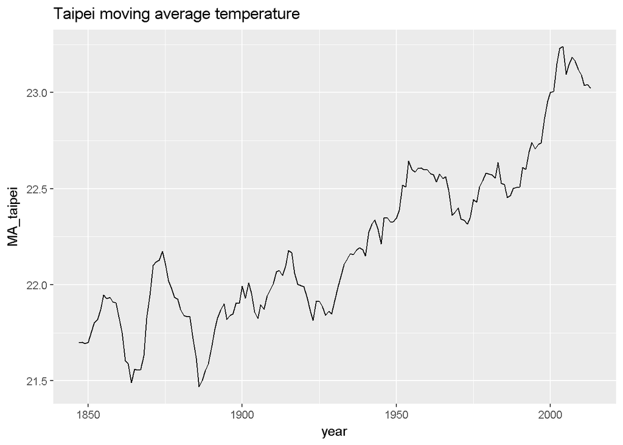

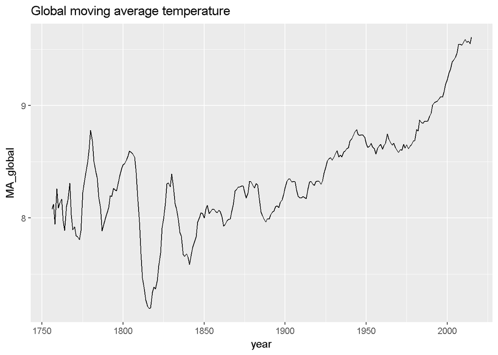

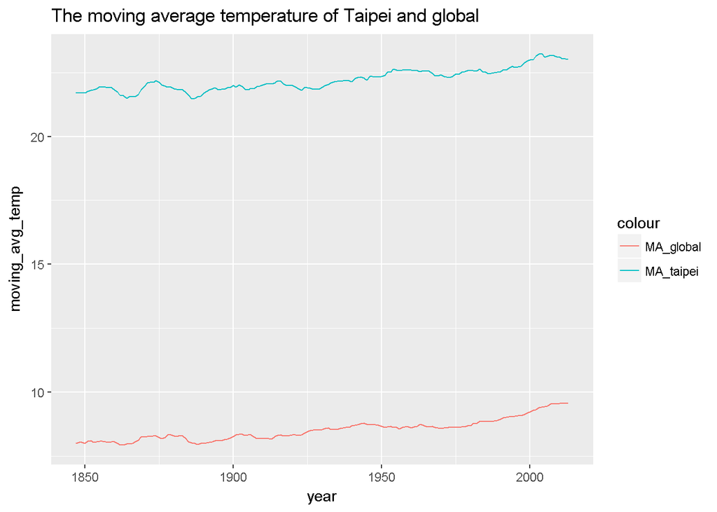

## 4. Observation

According to the graphs, there are some parts I would like to mention :

1. The average moving temperature of two dataset are **much various** to each other. As the global average moving temperature is always lower than 10 degree Celcius, Taipei’s average moving temperature is roughly between 21 degree Celsius and 23 degree Celsius, since it is located in the subtropical.
2. Whether it is global or Taipei ,the temperature has gradually **increased** since **1900**.
3. **Between 1750 and 1850**, the global moving average temperature **fluctuate very much**. It will be quite interesting to take a further research about it.
4. Compared with the global moving average, Taipei’s moving temperature changing tend to be **fluctuant** after **1850**.

## 5. Reference

1. https://blog.stranity.com.tw/2016/08/29/388/